# Sustainable food systems Analysis

3/15/2017

## Data we use

For test purposes we define some theoretical dimensions could influence Sustainable Food Systems. These dimensions were:

- **Nutritional aspects (NUTR)**
- **Human interventions (HINT)**
- **Food security (FSCY)**

On the other hand, **Sustainable Food Systems (SUFS)** is defined as the objective dimension.

## Human interventions (HINT)

Uses indicators of:

- Accessibility travel time to major cities
- Human Influence Index (HII) normalized by biome and realm

## Food security (FSCY)

Uses indicators of:

- Access to improved sanitation facilities (%)
- Access to improved water sources (%)
- Gross domestic product per capita, PPP (constant 2011 international $)
- Political stability and absence of violence/terrorism (index)

## PLS-PM in action - Model 1

Here it's very important to have or develop a theoretical model that link dimensions and take under consideration the relations between them.

For example, we used:

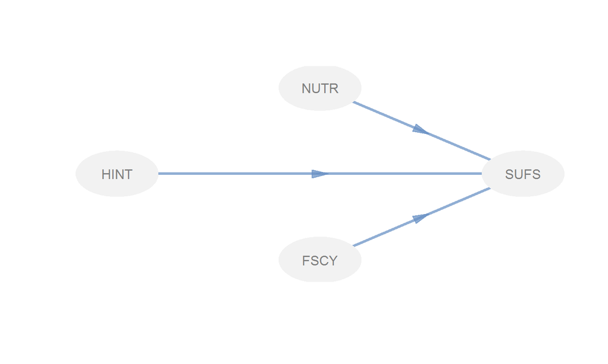

## PLS-PM in action - Model 1

Inner model estimates

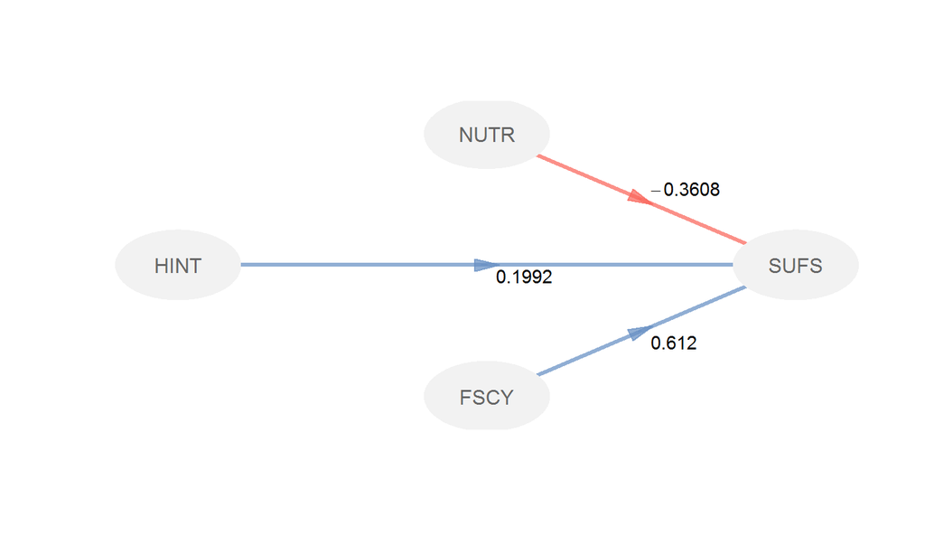

## PLS-PM in action - Model 1

Outer model estimates

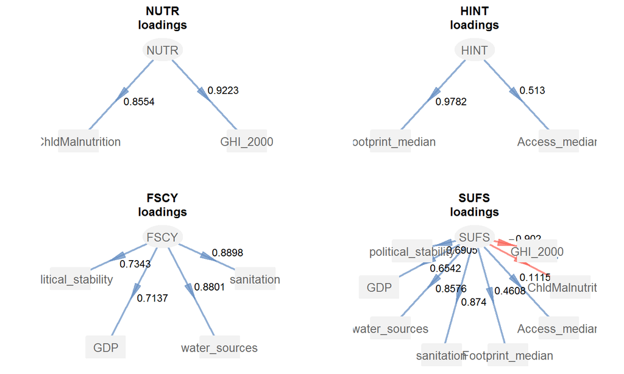

## PLS-PM in action - Model 1

Relationship between indices estimated

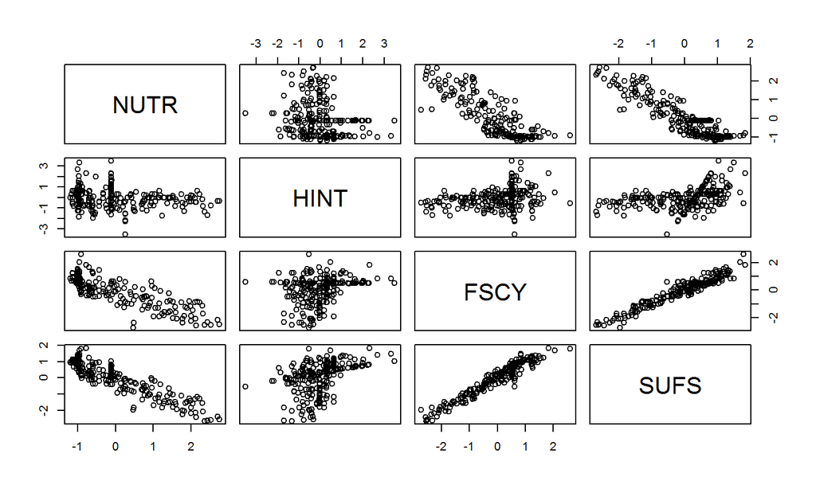

## PLS-PM in action - Model 1

Sustainable Food Systems index

[interactive chart not shown]

## PLS-PM in action - Model 1

Nutritional aspects index

[interactive chart not shown]

## PLS-PM in action - Model 1

Human interventions index

[interactive chart not shown]

## PLS-PM in action - Model 1

Food security index

[interactive chart not shown]

## PLS-PM in action - Model 2

Here we assume that there is a relation between Human Interventions to Food security and another between Food security and Nutritional aspects.

So, this is the theoretical model:

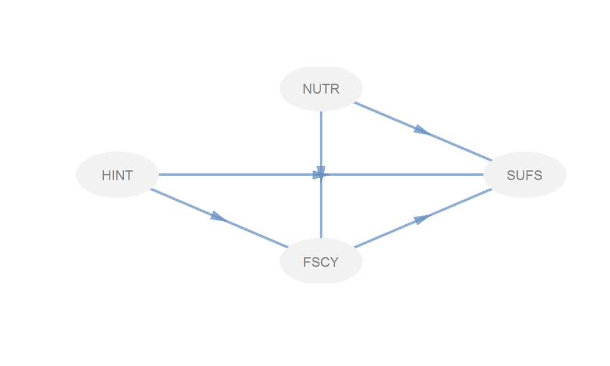

## PLS-PM in action - Model 2

Inner model estimates

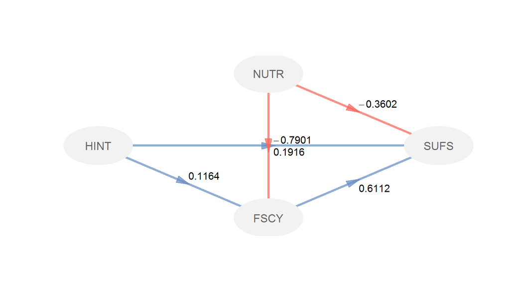

## PLS-PM in action - Model 2

Outer model estimates

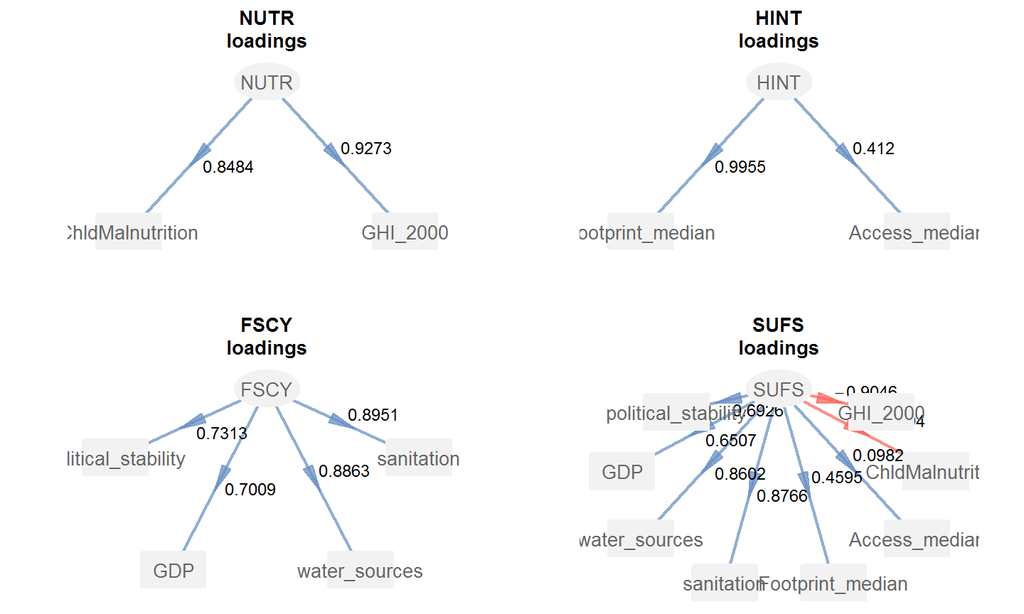

## PLS-PM in action - Model 2

Relationship between indices estimated

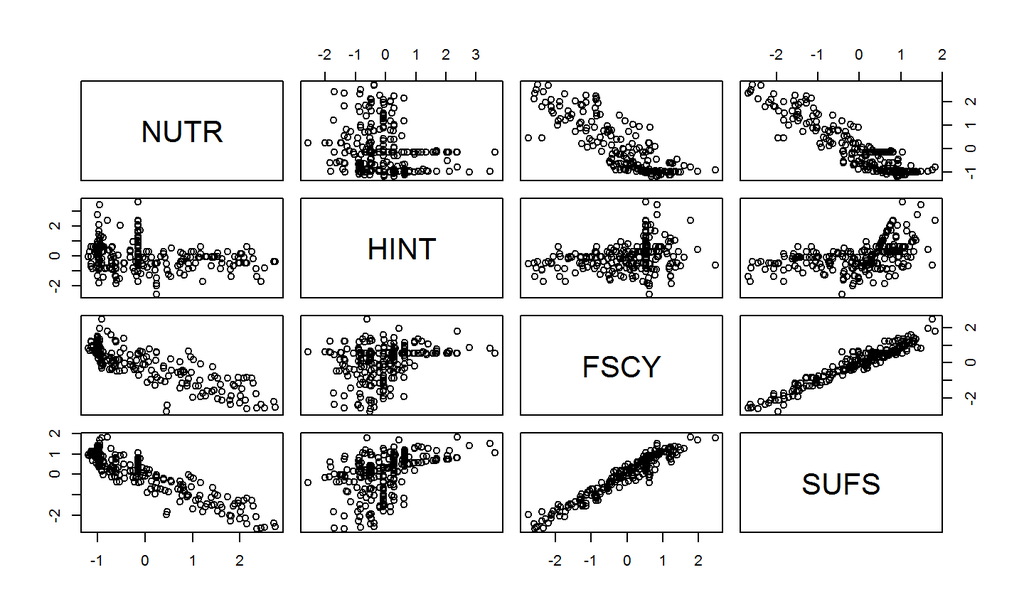

## PLS-PM in action - Model 2

Sustainable Food Systems index

[interactive chart not shown]

## PLS-PM in action - Model 2

Nutritional aspects index

[interactive chart not shown]

## PLS-PM in action - Model 2

Human interventions index

[interactive chart not shown]

## PLS-PM in action - Model 2

Food security index

[interactive chart not shown]

## Following steps

- Take in account the direction of each indicator in order to estimate appropriate indices
- Use theoretical information about how indices are related
- Implement Bayesian networks as a test or complementary measure of how interact all dimensions